# Ensemble Verification

Andrew Singleton

17/02/2022

```r
library(harp)
library(here)
library(dplyr)
```

# Ensemble verification works like deterministic

In fact, the work flow is exactly the same! So we start with reading in the forecast SQLite (FCTABLE) files. We are going to compare two models - IFSENS, and an experiment with HarmonEPS called REF. One thing to note is that the FCTABLE files for IFSENS were produced with an old version of harp where the default was to have one file for each lead time, so we need to have different templates for the file names. Fortunately we have some built in template names so we don’t have to write it out in full! You can see the templates with `show_file_templates()` and then choose a specific number to see in detail - we want the “fctable” and “fctable_eps” templates.

```r
show_file_templates()
```

```
## # A tibble: 33 × 2
##    template_name          template
##    <chr>                  <chr>
##  1 arome_arctic_extracted /lustre/storeB/immutable/archive/projects/metproducti…
##  2 arome_arctic_full      /lustre/storeB/immutable/archive/projects/metproducti…
##  3 arome_arctic_sfx       /lustre/storeB/immutable/archive/projects/metproducti…
##  4 fctable                {file_path}/{fcst_model}/{YYYY}/{MM}/FCTABLE_{paramet…
##  5 fctable_det            {file_path}/{det_model}/{YYYY}/{MM}/FCTABLE_{paramete…
##  6 fctable_eps            {file_path}/{eps_model}/{YYYY}/{MM}/FCTABLE_{paramete…
##  7 fctable_eps_all_cycles {file_path}/{eps_model}/{YYYY}/{MM}/FCTABLE_{paramete…
##  8 fctable_eps_all_leads  {file_path}/{eps_model}/{YYYY}/{MM}/FCTABLE_{paramete…
##  9 glameps_grib           {file_path}/{eps_model}/{sub_model}/{YYYY}/{MM}/{DD}/…
## 10 harmoneps_grib         {file_path}/{YYYY}/{MM}/{DD}/{HH}/mbr{MBR3}/fc{YYYY}{…
## 11 harmoneps_grib_fp      {file_path}/{YYYY}/{MM}/{DD}/{HH}/mbr{MBR3}/fc{YYYY}{…
## 12 harmoneps_grib_sfx     {file_path}/{YYYY}/{MM}/{DD}/{HH}/mbr{MBR3}/fc{YYYY}{…
```

[output cut: 21 more lines]

```r
show_file_templates(4)
```

```
##
## template_name:
##  fctable
##
## template:
##  {file_path}/{fcst_model}/{YYYY}/{MM}/FCTABLE_{parameter}_{YYYY}{MM}_{HH}.sqlite
```

```r
show_file_templates(6)
```

```
##
## template_name:
##  fctable_eps
##
## template:
##  {file_path}/{eps_model}/{YYYY}/{MM}/FCTABLE_{parameter}_{YYYY}{MM}_{HH}+{LDT3}.sqlite
```

We are going to verify for 6 hour accumulated precipitation.

```r
pcp6h <- read_point_forecast(
  start_date    = 2018030800,
  end_date      = 2018033100,
  by            = "1d",
  fcst_model    = c("REF", "IFSENS"),
  fcst_type     = "eps",
  parameter     = "AccPcp6h",
  file_path     = here("data/FCTABLE"),
  file_template = list(
    REF    = "fctable",
    IFSENS = "fctable_eps"
  )
)
```

And now select the common cases

```r
pcp6h <- common_cases(pcp6h)
```

And now the observations

```r
pcp6h_obs <- read_point_obs(
  start_date = first_validdate(pcp6h),
  end_date   = last_validdate(pcp6h),
  parameter  = "AccPcp6h",
  stations   = pull_stations(pcp6h),
  obs_path   = here("data/OBSTABLE")
)
```

We see that 1 observation was removed due to the gross error check. The output of `read_point_obs()` as some attributes - we can see them using the `attributes()` function and pick out a specific one with `attr()`

```r
attributes(pcp6h_obs)
```

[output not shown]

[output cut: 387 more lines]

```r
attr(pcp6h_obs, "bad_obs")
```

```
## # A tibble: 1 × 7
##   validdate             SID   lon   lat  elev units  AccPcp6h
##   <dttm>              <int> <dbl> <dbl> <dbl> <chr>     <dbl>
## 1 2018-03-24 18:00:00  1062  25.0  76.5    10 kg/m^2     -0.9
```

Now we can join the forecasts and observations together

```r
pcp6h <- join_to_fcst(pcp6h, pcp6h_obs)
```

We can do scatter plot - by default it will split it up by member

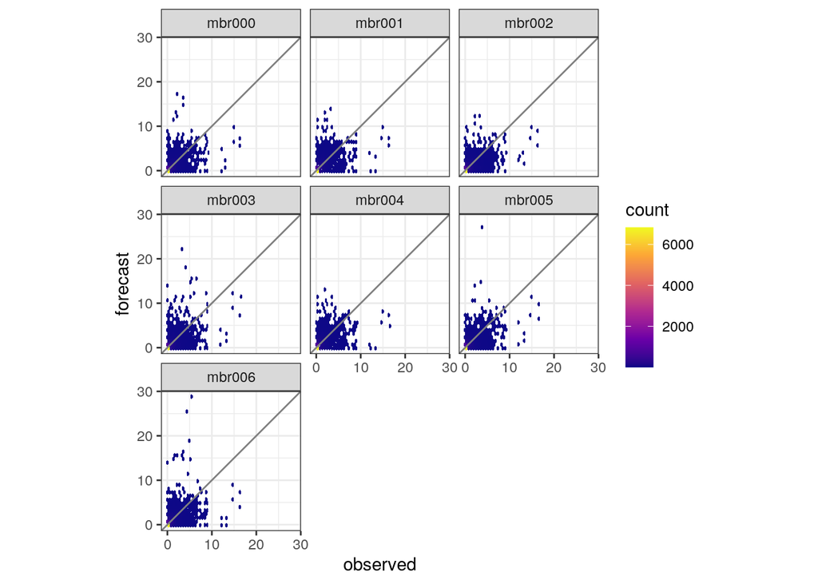

```r
plot_scatter(pcp6h, REF, AccPcp6h)
```

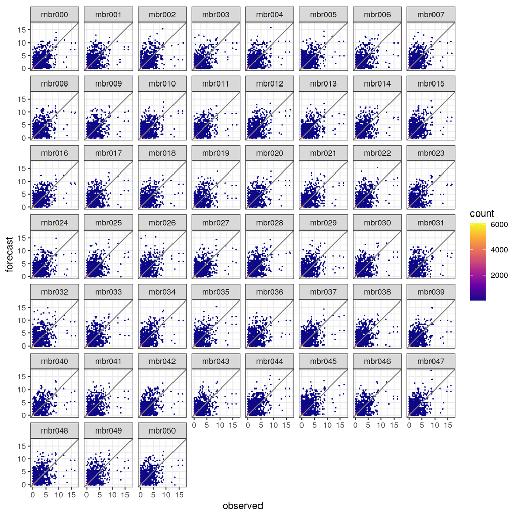

```r
plot_scatter(pcp6h, IFSENS, AccPcp6h)
```

Or you can combine all members by setting facet_members = FALSE

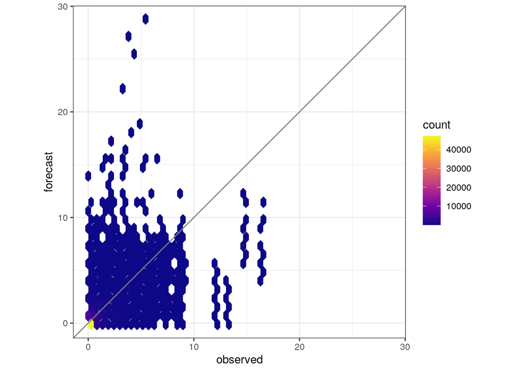

```r
plot_scatter(pcp6h, REF, AccPcp6h, facet_members = FALSE)
```

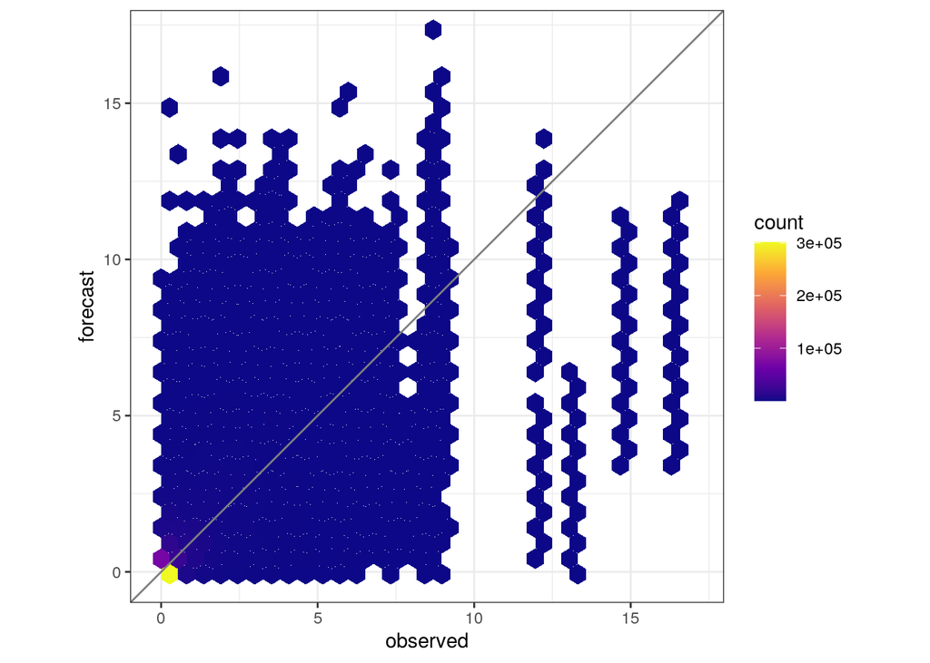

```r
plot_scatter(pcp6h, IFSENS, AccPcp6h, facet_members = FALSE)
```

And now verify with `ens_verify()`

```r
verif <- ens_verify(pcp6h, AccPcp6h)
```

And do some basic plots

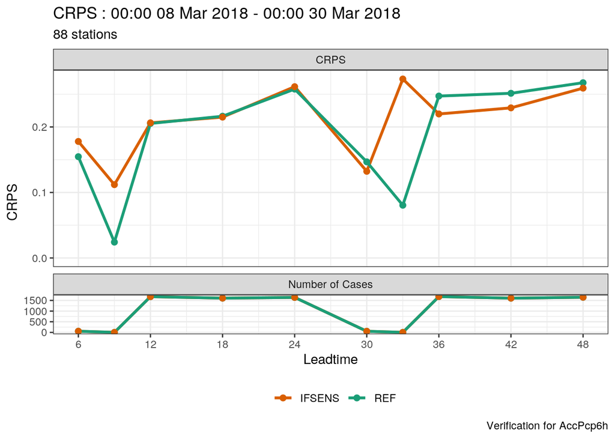

```r
plot_point_verif(verif, spread_skill)
plot_point_verif(verif, crps)
```

[output not shown]

We see that there are a number of lead times with very few cases - we can remove these using `filter_list()`

```r
verif <- filter_list(verif, num_cases > 100)
```

For rank histograms comparing models with different numbers of members is a bit ugly. However we can turn it into a relative rank histogram by setting `rank_is_relative = TRUE`. We can also normalize and change the plot type to a “lollipop” plot.

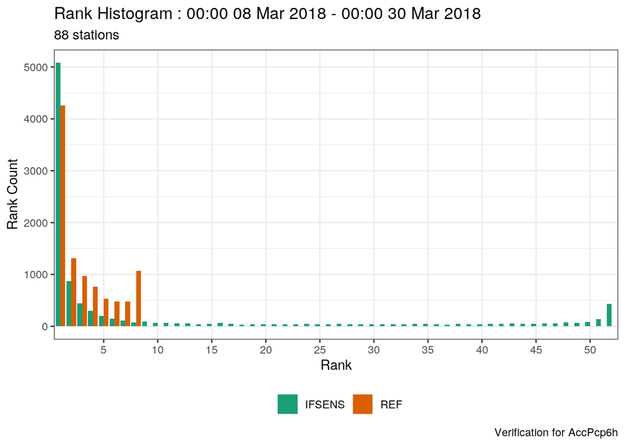

```r
plot_point_verif(verif, rank_histogram)
```

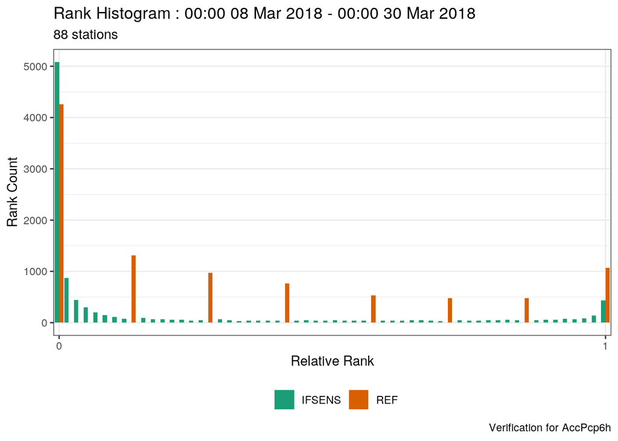

```r
plot_point_verif(verif, rank_histogram, rank_is_relative = TRUE)
```

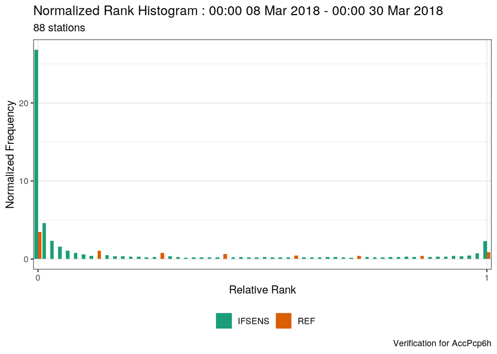

```r
plot_point_verif(verif, normalized_rank_histogram, rank_is_relative = TRUE)
```

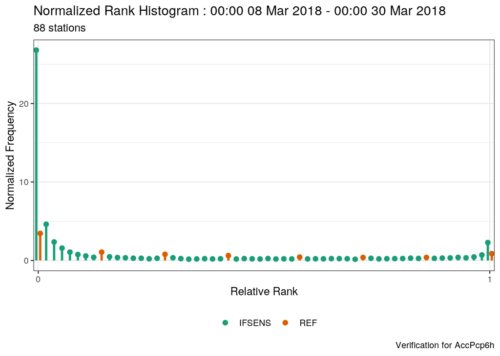

```r
plot_point_verif(
  verif, normalized_rank_histogram,
  rank_is_relative = TRUE, rank_hist_type = "lollipop"
)
```

By default, `ens_verify()` computes summary deterministic scores for each member, so we can plot those too, but things can get a bit difficult to see… so requires some extra work…

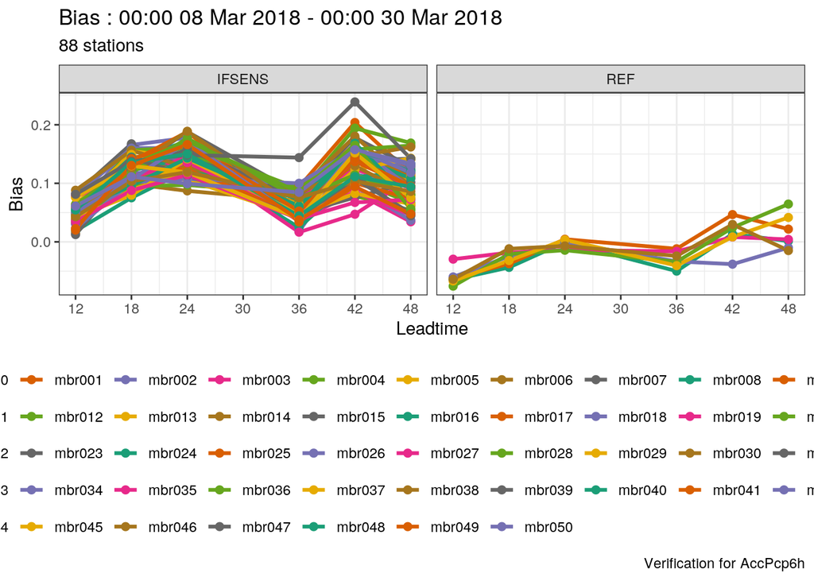

```r
plot_point_verif(
  verif,
  bias,
  verif_type = "det",
  colour_by = member,
  facet_by  = vars(mname),
  num_legend_rows = 5
)
```

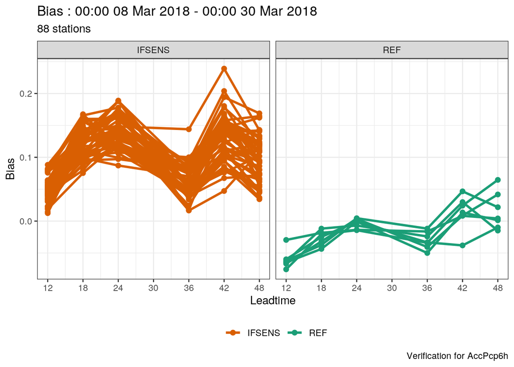

```r
plot_point_verif(
  verif,
  bias,
  verif_type = "det",
  group      = member,
  facet_by   = vars(mname)
)
```

So we need to tell it which is the control - we can use `mutate_list()` to mutate data frames in a harp verification object - if the columns you specify aren’t found it silently tries the next data frame. We `case_when()` to selectively mutate based on the contents of a column.

```r
verif <- mutate_list(
  verif,
  member_type = case_when(
    member == "mbr000" ~ "control",
    TRUE               ~ "perturbed"
  )
)
```

And now we can highlight the control member

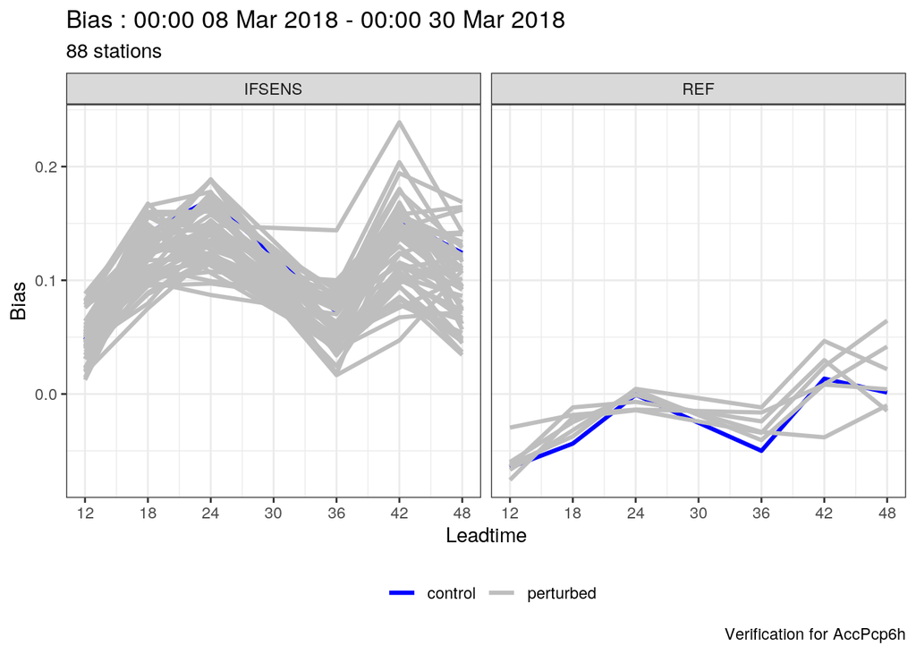

```r
plot_point_verif(
  verif,
  bias,
  verif_type = "det",
  colour_by  = member_type,
  group      = member,
  point_size = 0,
  facet_by   = vars(mname),
  colour_table = data.frame(
    member_type = c("control", "perturbed"),
    colour      = c("blue", "grey")
  )
)
```

The control member can look a bit hidden so we might have to draw it again (automatic fix coming soon!)

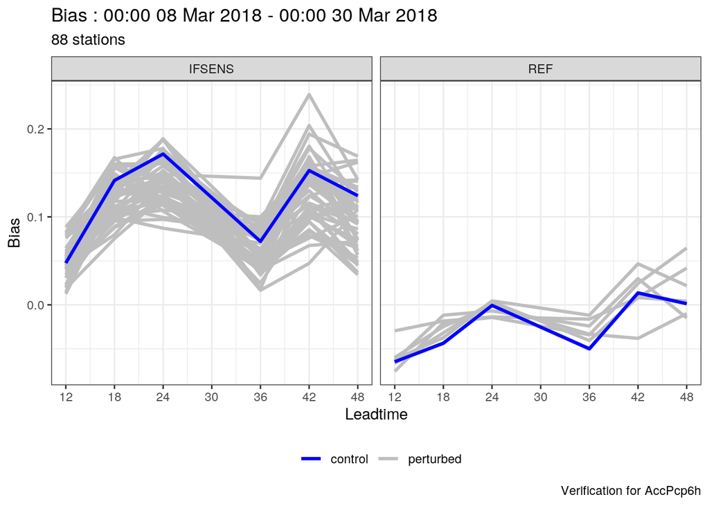

```r
plot_point_verif(
  verif,
  bias,
  verif_type = "det",
  colour_by  = member_type,
  group      = member,
  point_size = 0,
  facet_by   = vars(mname),
  colour_table = data.frame(
    member_type = c("control", "perturbed"),
    colour      = c("blue", "grey")
  )
) +
  geom_line(
    data   = filter(verif$det_summary_scores, member == "mbr000"),
    colour = "blue",
    size   = 1.1
  )
```

Like deterministic, we can compute categorical scores by adding some thresholds - we could get thresholds by computing quantiles of the observed quantities.

```r
thresholds <-quantile(pcp6h_obs$AccPcp6h, c(0.1, 0.25, 0.5, 0.75, 0.9))
thresholds
```

```
## 10% 25% 50% 75% 90%
## 0.0 0.0 0.0 0.3 1.2
```

There are a lot of zeroes, so maybe just do it on precip > 0

```r
thresholds <-quantile(
  filter(pcp6h_obs, AccPcp6h > 0)$AccPcp6h,
  c(0.1, 0.25, 0.5, 0.75, 0.9)
)
thresholds
```

```
##  10%  25%  50%  75%  90%
## 0.10 0.20 0.60 1.40 2.79
```

Now we verify with thresholds and we get a bunch of new scores

```r
verif <- ens_verify(pcp6h, AccPcp6h, thresholds = thresholds)
```

Again, when we plot we have to facet by threshold

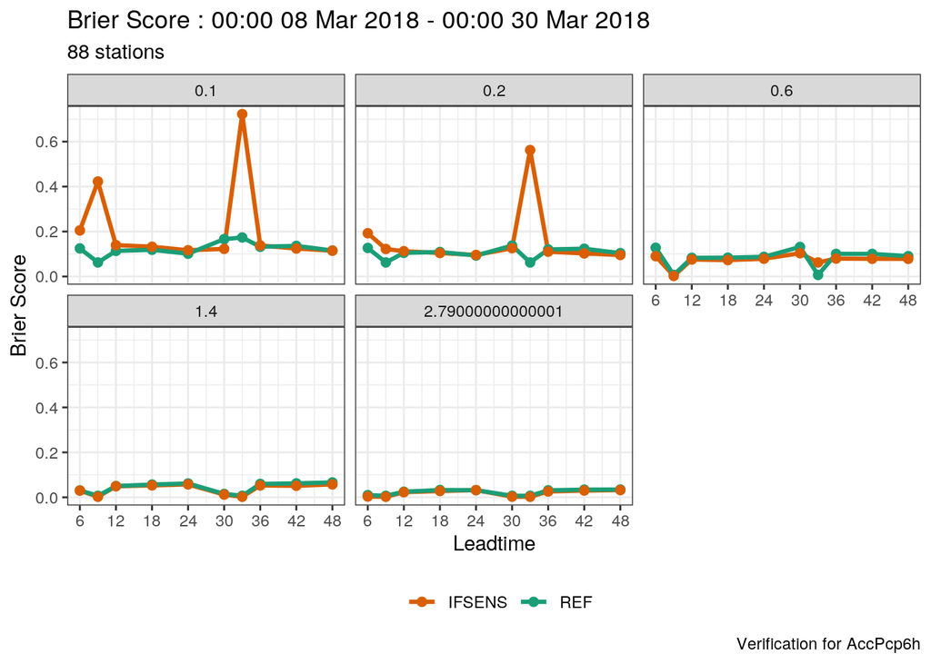

```r
plot_point_verif(verif, brier_score, facet_by = vars(threshold))
```

But let’s get rid of the points without much data - for threshold scores we need to filter on `num_cases_total`

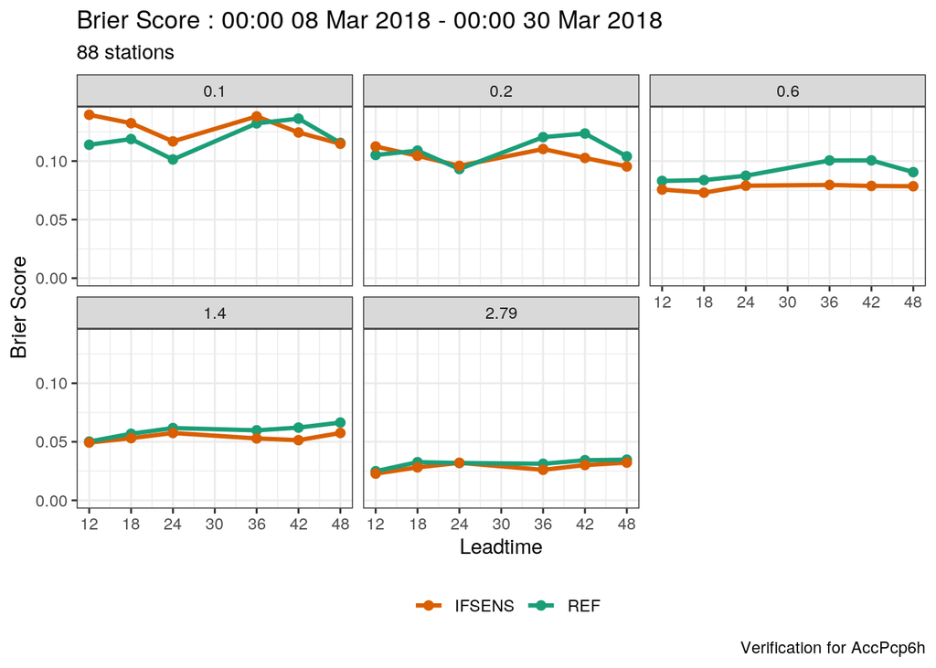

```r
verif <- filter_list(verif, num_cases_total > 100)
plot_point_verif(verif, brier_score, facet_by = vars(round(threshold, 2)))
```

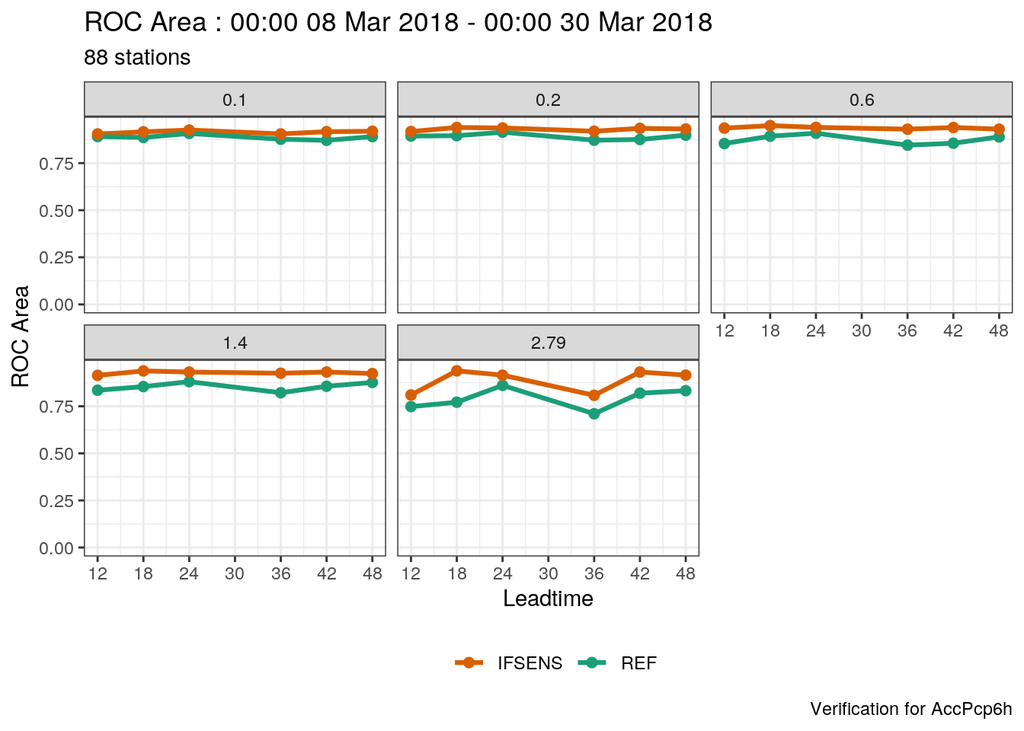

```r
plot_point_verif(verif, roc_area, facet_by = vars(round(threshold, 2)))
```

For some scores we need to filter / facet by lead time as well!

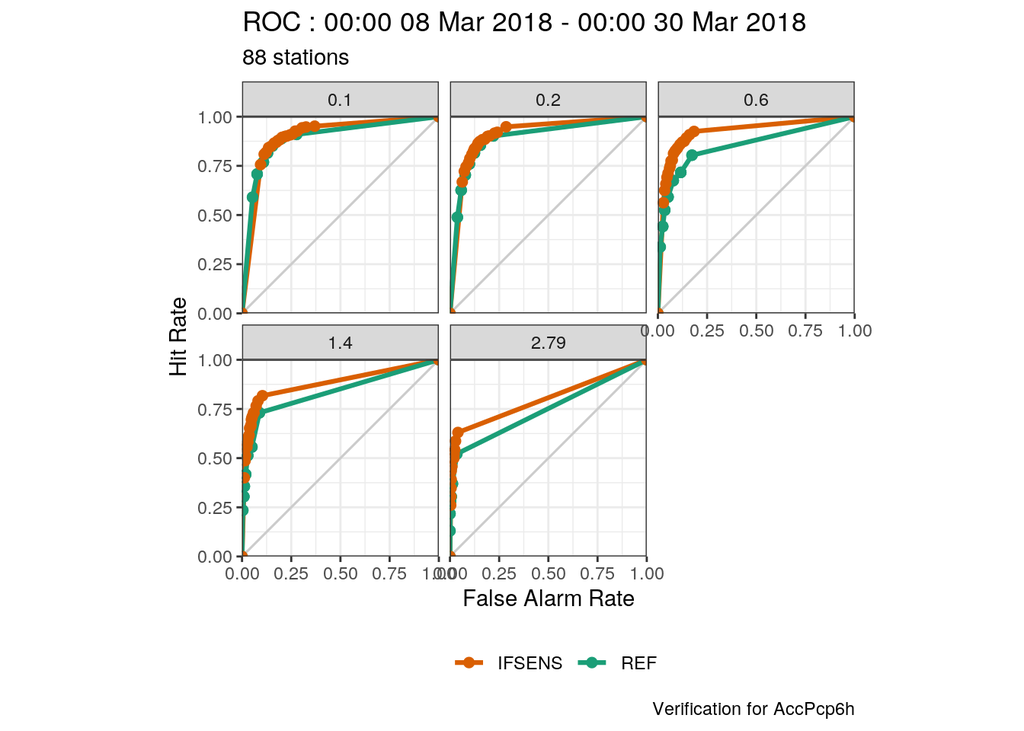

```r
plot_point_verif(
  verif, roc,
  facet_by = vars(round(threshold, 2)),
  filter_by = vars(leadtime == 12)
)
```

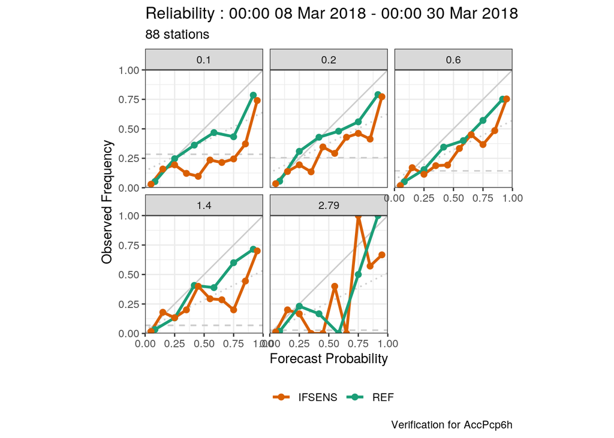

```r
plot_point_verif(
  verif, reliability,
  facet_by = vars(round(threshold, 2)),
  filter_by = vars(leadtime == 12)
)
```

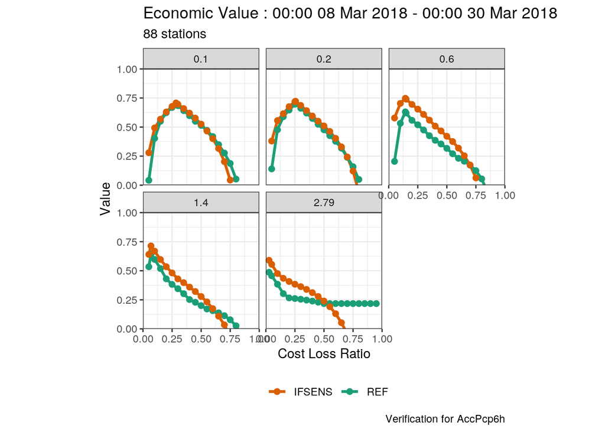

```r
plot_point_verif(
  verif, economic_value,
  facet_by = vars(round(threshold, 2)),
  filter_by = vars(leadtime == 12)
)
```

## Fair scores

Comparing models with different numbers of members is not a fair comparison. For some scores (CRPS and Brier Score), the scores can be scaled to what would be expected if the models had a certain number of ensemble members, or even infinite ensemble members. In `ens_verify()` this is done by adding something for the `num_ref_members` argument. Here we scale the scores so that both models have 51 members.

```r
verif <- ens_verify(
  pcp6h,
  AccPcp6h,
  thresholds      = thresholds,
  num_ref_members = 51
)
select_list(verif, mname, leadtime, matches("brier|crps|fair"))
```

```
## $ens_summary_scores
## # A tibble: 20 × 6
##    mname  leadtime fair_crps   crps crps_potential crps_reliability
##    <chr>     <int>     <dbl>  <dbl>          <dbl>            <dbl>
##  1 REF           6    0.145  0.155      0.0919               0.0627
##  2 REF           9    0.0159 0.0242     0                    0.0242
##  3 REF          12    0.194  0.205      0.176                0.0293
##  4 REF          18    0.203  0.216      0.190                0.0266
##  5 REF          24    0.241  0.258      0.225                0.0332
##  6 REF          30    0.133  0.147      0.105                0.0418
##  7 REF          33    0.0552 0.0805     0.0000158            0.0805
##  8 REF          36    0.232  0.247      0.214                0.0332
##  9 REF          42    0.232  0.251      0.224                0.0274
## 10 REF          48    0.245  0.268      0.240                0.0275
## 11 IFSENS        6    0.178  0.178      0.0974               0.0805
## 12 IFSENS        9    0.112  0.112      0.00000108           0.112
## 13 IFSENS       12    0.206  0.206      0.160                0.0465
## 14 IFSENS       18    0.215  0.215      0.165                0.0502
## 15 IFSENS       24    0.261  0.261      0.200                0.0614
## 16 IFSENS       30    0.132  0.132      0.0972               0.0351
## 17 IFSENS       33    0.273  0.273      0                    0.273
## 18 IFSENS       36    0.220  0.220      0.189                0.0308
## 19 IFSENS       42    0.229  0.229      0.193                0.0365
## 20 IFSENS       48    0.259  0.259      0.226                0.0334
##
## $ens_threshold_scores
## # A tibble: 100 × 8
##    mname leadtime fair_brier_score brier_score brier_skill_sco… brier_score_rel…
##    <chr>    <int>            <dbl>       <dbl>            <dbl>            <dbl>
##  1 REF          6           0.123       0.125             0.387          0.0374
##  2 REF          9           0.0523      0.0625         -Inf              0.0625
##  3 REF         12           0.111       0.114             0.440          0.00946
##  4 REF         18           0.115       0.119             0.434          0.00924
##  5 REF         24           0.0962      0.101             0.528          0.00577
##  6 REF         30           0.154       0.166             0.202          0.0564
##  7 REF         33           0.148       0.174          -Inf              0.174
##  8 REF         36           0.126       0.132             0.343          0.0134
##  9 REF         42           0.128       0.136             0.360          0.0107
## 10 REF         48           0.108       0.116             0.458          0.00495
## # … with 90 more rows, and 2 more variables: brier_score_resolution <dbl>,
```

[output cut: 11 more lines]

```
##  6 REF          6
##  7 REF          6
##  8 REF          9
##  9 REF          9
## 10 REF          9
## # … with 570 more rows
##
## attr(,"parameter")
## [1] "AccPcp6h"
## attr(,"start_date")
## [1] "2018030800"
## attr(,"end_date")
## [1] "2018033000"
## attr(,"num_stations")
## [1] 88
```

Or we can scale both models to have an infinite number of members (only works for CRPS)

```r
verif <- ens_verify(
  pcp6h,
  AccPcp6h,
  thresholds      = thresholds,
  num_ref_members = Inf
)
select_list(verif, mname, leadtime, matches("brier|crps|fair"))
```

```
## $ens_summary_scores
## # A tibble: 20 × 6
##    mname  leadtime fair_crps   crps crps_potential crps_reliability
##    <chr>     <int>     <dbl>  <dbl>          <dbl>            <dbl>
##  1 REF           6    0.143  0.155       0.0942              0.0604
##  2 REF           9    0.0145 0.0242      0                   0.0242
##  3 REF          12    0.192  0.205       0.177               0.0284
##  4 REF          18    0.200  0.216       0.190               0.0265
##  5 REF          24    0.238  0.258       0.225               0.0330
##  6 REF          30    0.130  0.147       0.105               0.0418
##  7 REF          33    0.0511 0.0805      0.0000155           0.0805
##  8 REF          36    0.230  0.247       0.214               0.0335
##  9 REF          42    0.228  0.251       0.224               0.0271
## 10 REF          48    0.241  0.268       0.240               0.0277
## 11 IFSENS        6    0.177  0.178       0.100               0.0777
## 12 IFSENS        9    0.110  0.112       0                   0.112
## 13 IFSENS       12    0.205  0.206       0.160               0.0468
## 14 IFSENS       18    0.213  0.215       0.165               0.0503
## 15 IFSENS       24    0.259  0.261       0.200               0.0610
## 16 IFSENS       30    0.131  0.132       0.0984              0.0339
## 17 IFSENS       33    0.270  0.273       0                   0.273
## 18 IFSENS       36    0.217  0.220       0.189               0.0308
## 19 IFSENS       42    0.226  0.229       0.193               0.0366
## 20 IFSENS       48    0.256  0.259       0.226               0.0336
##
## $ens_threshold_scores
## # A tibble: 100 × 8
##    mname leadtime fair_brier_score brier_score brier_skill_sco… brier_score_rel…
##    <chr>    <int>            <dbl>       <dbl>            <dbl>            <dbl>
##  1 REF          6              NaN      0.125             0.387          0.0374
##  2 REF          9              NaN      0.0625         -Inf              0.0625
##  3 REF         12              NaN      0.114             0.440          0.00946
##  4 REF         18              NaN      0.119             0.434          0.00924
##  5 REF         24              NaN      0.101             0.528          0.00577
##  6 REF         30              NaN      0.166             0.202          0.0564
##  7 REF         33              NaN      0.174          -Inf              0.174
##  8 REF         36              NaN      0.132             0.343          0.0134
##  9 REF         42              NaN      0.136             0.360          0.0107
## 10 REF         48              NaN      0.116             0.458          0.00495
## # … with 90 more rows, and 2 more variables: brier_score_resolution <dbl>,
```

[output cut: 11 more lines]

```
##  6 REF          6
##  7 REF          6
##  8 REF          9
##  9 REF          9
## 10 REF          9
## # … with 570 more rows
##
## attr(,"parameter")
## [1] "AccPcp6h"
## attr(,"start_date")
## [1] "2018030800"
## attr(,"end_date")
## [1] "2018033000"
## attr(,"num_stations")
## [1] 88
```